# Statistical Learning Project

Top 10 people in socioeconomic and physiological health index:

```r
# Get the indices of the top 10 observations along the first principal component
top_indices2 <- order(pca$x[,2], decreasing = TRUE)[1:10]

# Use these indices to subset the original dataset and view the variable information
top_observations2 <- normal_cleaned_data[top_indices2, ]

# Display the top observations
print(top_observations2)
```

```
## # A tibble: 10 × 13
##    Gender   Age HHIncomeMid Weight Height   BMI Pulse BPSysAve BPDiaAve TotChol
##    <fct>  <int>       <dbl>  <dbl>  <dbl> <dbl> <int>    <int>    <int>   <dbl>
##  1 female    80       30000   48.5   144.  23.3    56      141       45    6.7
##  2 female    80       12500   42.5   146.  19.8    66      158       52    5.12
##  3 female    80      100000   40.2   148.  18.3    52      148       64    6.18
##  4 female    80       22500   43.5   156.  17.8    64      104       46    5.02
##  5 female    80       40000   45.6   163.  17.2    50      122       48    4.45
##  6 female    80       22500   46.3   156.  18.9    56      143       61    6.49
##  7 female    69        7500   37     156.  15.2    74      111       47    5.74
##  8 female    79       30000   51.3   157.  20.9    56      140       63    4.01
##  9 female    70        7500   46.2   149.  20.9    62      153       71    5.09
## 10 female    80      100000   45.3   148   20.7    66      146       70    5.61
## # ℹ 3 more variables: UrineVol1 <int>, SleepAdjusted <dbl>, PulseAgeRatio <dbl>
```

Fourth component:

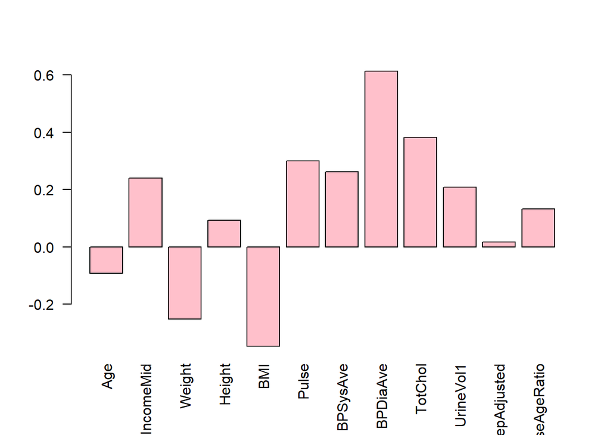

```r
barplot(pca$rotation[,4], las=2, col="pink")
```

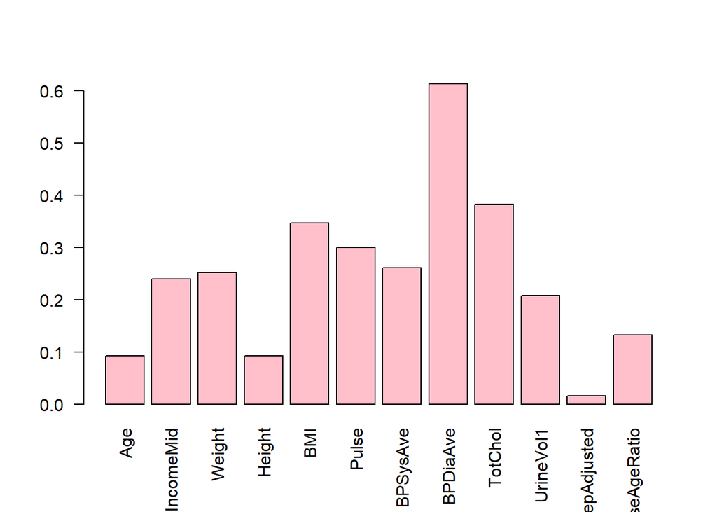

```r
barplot(abs(pca$rotation[,4]), las=2, col="pink")
```

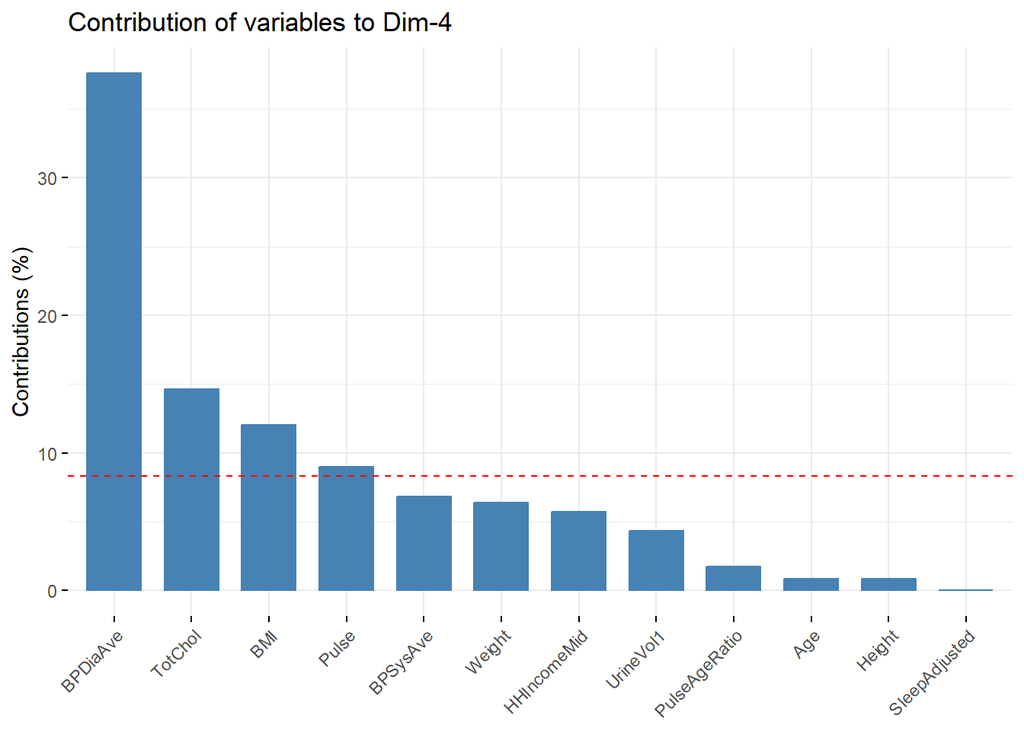

```r
fviz_contrib(pca, choice = "var", axes = 4)
```

We can observe that the most relevant variables for the fourth component are: BPDiaAVe, Pulse, TotChol and BMI

The fourth component appears to represent a cardiovascular and metabolic health risk index.

Fifth component:

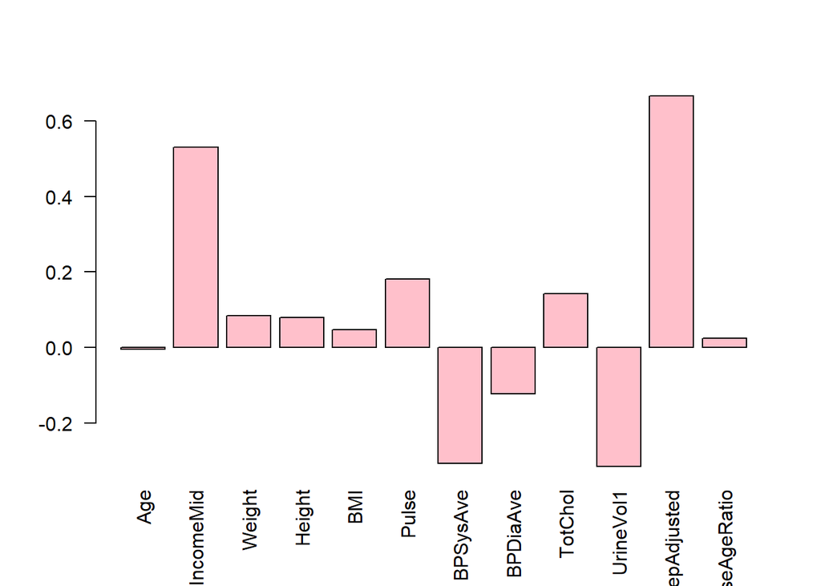

```r
barplot(pca$rotation[,5], las=2, col="pink")
```

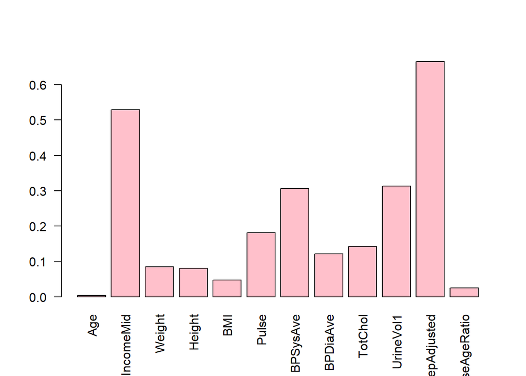

```r
barplot(abs(pca$rotation[,5]), las=2, col="pink")
```

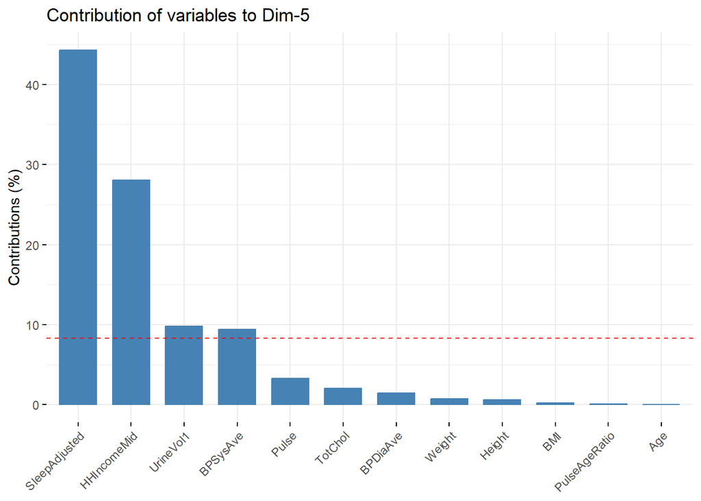

```r
fviz_contrib(pca, choice = "var", axes = 5)
```

The fifth component seems to represent a lifestyle and socioeconomic health index.

Sixth component:

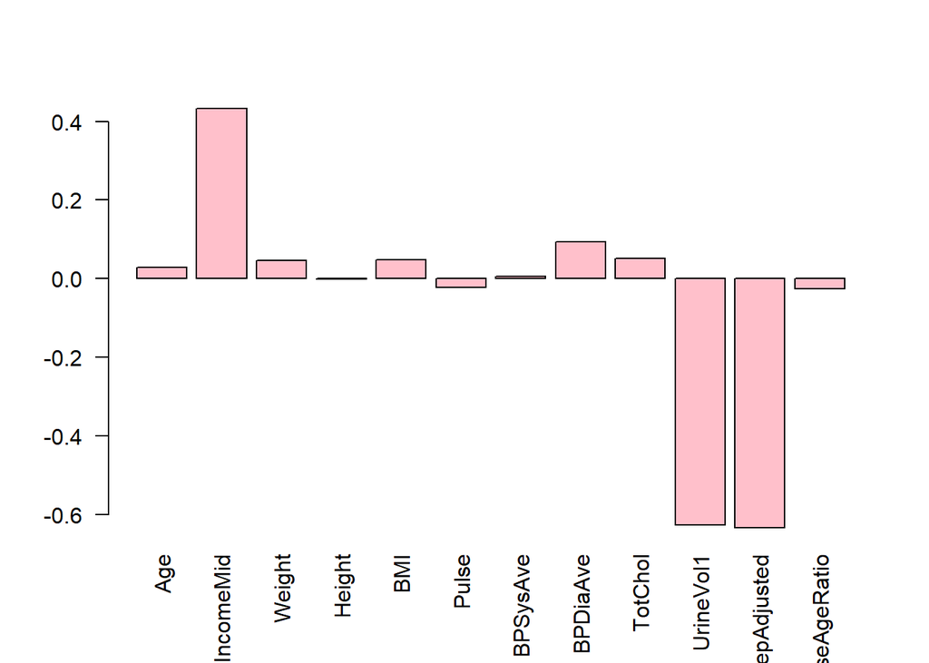

```r
barplot(pca$rotation[,6], las=2, col="pink")
```

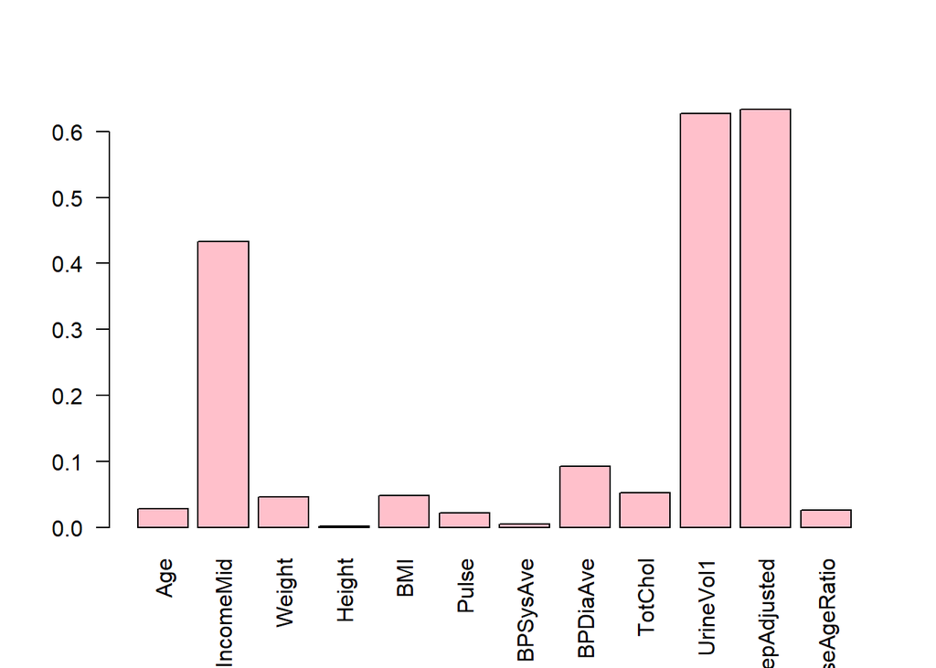

```r
barplot(abs(pca$rotation[,6]), las=2, col="pink")
```

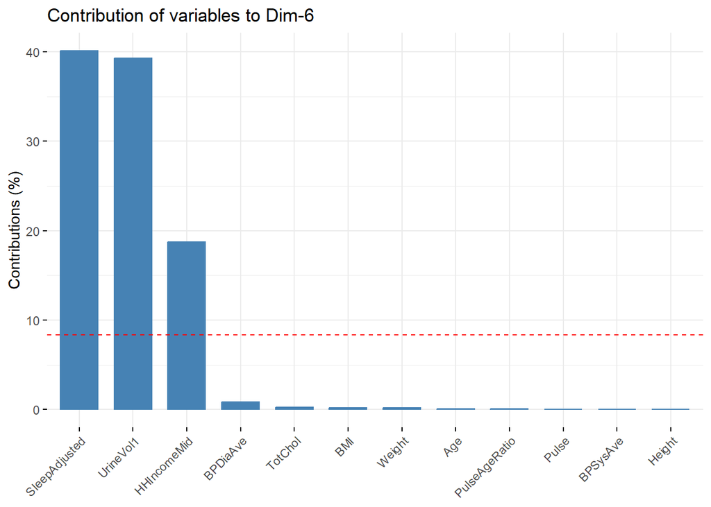

```r
fviz_contrib(pca, choice = "var", axes = 6)
```

We can observe that the most relevant variables for the sixth component are: UrineVol1, SleepAdjusted and HHIncomeMid

PC6 may represent a component associated with lifestyle and health factors influenced by socioeconomic status, sleep patterns, and physical health indicators.

Seventh component:

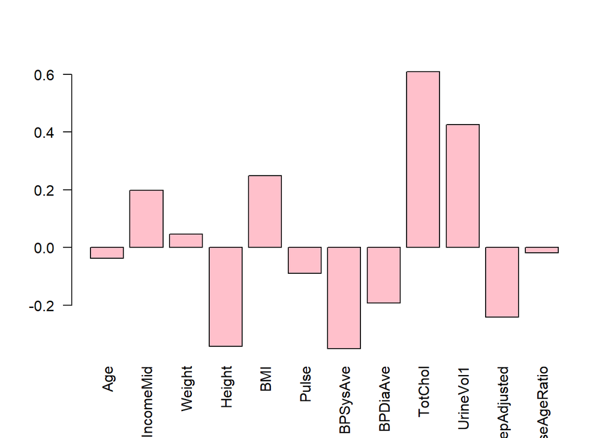

```r
barplot(pca$rotation[,7], las=2, col="pink")
```

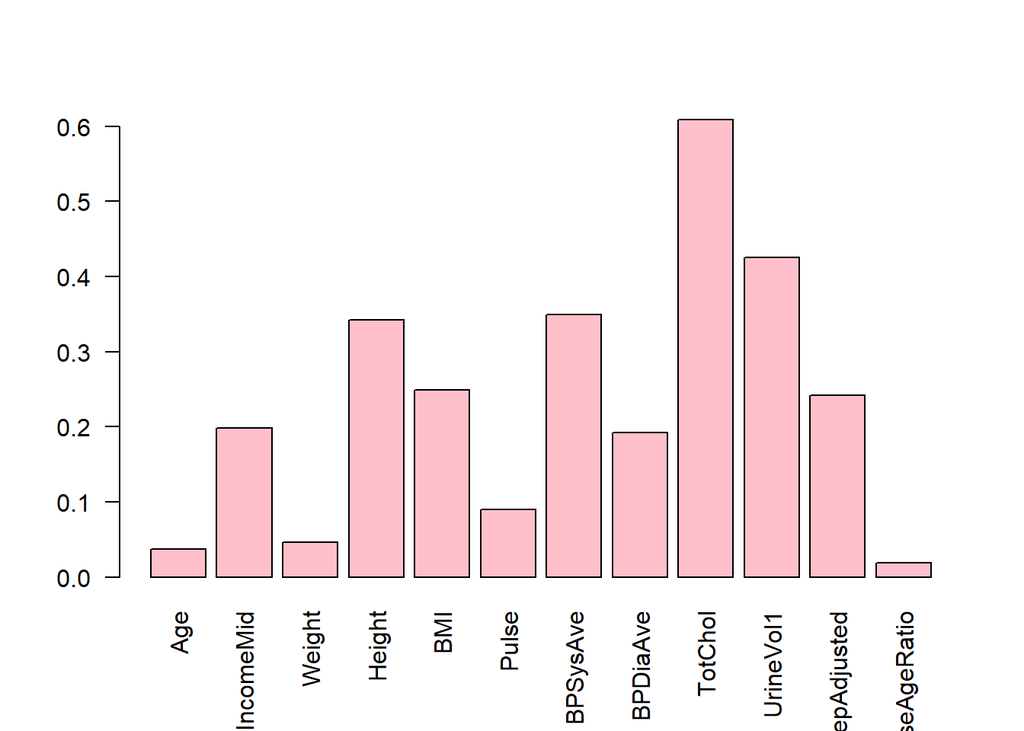

```r
barplot(abs(pca$rotation[,7]), las=2, col="pink")
```

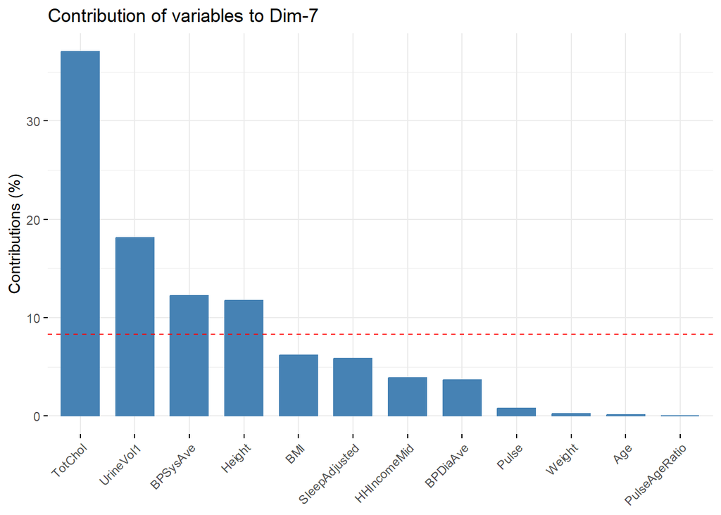

```r
fviz_contrib(pca, choice = "var", axes = 7)
```

PC7 might capture aspects of cardiovascular and metabolic health, influenced by both physiological markers (like cholesterol and blood pressure) and lifestyle elements (like sleep). This component could help differentiate individuals based on combined cardiovascular risk factors and body-related attributes.

# Factor analysis

The more factors that we have the better the variance explained will be, but this can lead to overfitting. Hence, we need to find the balance between the two.

```r
# Factor analysis with all numeric data(should limit them)
fa_result <- factanal(final_cleaned_data, factors = 4, rotation="varimax", scores="regression", lower = 0.01)
fa_result
```

```
##
## Call:
## factanal(x = final_cleaned_data, factors = 4, scores = "regression",     rotation = "varimax", lower = 0.01)
##
## Uniquenesses:
##           Age   HHIncomeMid        Weight        Height           BMI
##         0.023         0.965         0.010         0.010         0.010
##         Pulse      BPSysAve      BPDiaAve       TotChol     UrineVol1
##         0.010         0.775         0.916         0.912         0.962
## SleepAdjusted PulseAgeRatio
##         0.955         0.010
##
## Loadings:
##               Factor1 Factor2 Factor3 Factor4
## Age            0.984
## HHIncomeMid                    0.176
## Weight         0.148   0.924   0.335
## Height                 0.167   0.974   0.120
## BMI            0.178   0.963  -0.180
## Pulse                         -0.220   0.965
## BPSysAve       0.446   0.151
## BPDiaAve       0.168   0.157   0.108   0.139
## TotChol        0.280
## UrineVol1                      0.167
## SleepAdjusted  0.210
## PulseAgeRatio -0.943                   0.313
##
##                Factor1 Factor2 Factor3 Factor4
## SS loadings      2.274   1.871   1.225   1.076
## Proportion Var   0.190   0.156   0.102   0.090
## Cumulative Var   0.190   0.345   0.448   0.537
##
## Test of the hypothesis that 4 factors are sufficient.
## The chi square statistic is 2610.82 on 24 degrees of freedom.
## The p-value is 0
```

For using all the variables available, we can see that the best solution will be using four factors as we will get a relatively good variance explained and not be in great risk of overfitting. However, as we can see by the chi square statistics, this model does not have the best fit. Changing the rotation or the scores here doesn’t really affect the model. We can now try and remove some of the variables that are not well explained by the model. To do that we need to check the uniqueness of this factor analysis.

```r
fa_result$uniquenesses
```

```
##           Age   HHIncomeMid        Weight        Height           BMI
##    0.02313887    0.96487502    0.01000000    0.01000000    0.01000000
##         Pulse      BPSysAve      BPDiaAve       TotChol     UrineVol1
##    0.01000000    0.77499685    0.91596888    0.91240573    0.96170938
## SleepAdjusted PulseAgeRatio
##    0.95476077    0.01000000
```

Judging by the uniqueness of the variables, we can see that HHIncomeMid, TotChol, UrineVol1 and SleepAdjusted all have above 0.91 uniqueness, which means that more 91% of the variance in these variable cannot be explained by the model. As we cannot find better models by changing the factors, rotation or scores, we can remove those variables.

```r
final_cleaned_data1 = final_cleaned_data %>% dplyr::select(-HHIncomeMid, -TotChol,
                                                    -UrineVol1, -SleepAdjusted)
fa_result_1_f4 <- factanal(final_cleaned_data1, factors = 4, rotation="promax", scores="regression",
                        lower = 0.01)
fa_result_1_f4
```

```
##
## Call:
## factanal(x = final_cleaned_data1, factors = 4, scores = "regression",     rotation = "promax", lower = 0.01)
##
## Uniquenesses:
##           Age        Weight        Height           BMI         Pulse
##         0.010         0.010         0.010         0.010         0.010
##      BPSysAve      BPDiaAve PulseAgeRatio
##         0.769         0.922         0.021
##
## Loadings:
##               Factor1 Factor2 Factor3 Factor4
## Age            1.024                   0.109
## Weight                 0.881   0.293
## Height                         1.011
## BMI                    1.047  -0.250
## Pulse                                  0.987
## BPSysAve       0.442
## BPDiaAve       0.129   0.113   0.135   0.138
## PulseAgeRatio -0.944                   0.171
##
##                Factor1 Factor2 Factor3 Factor4
## SS loadings      2.156   1.902   1.194   1.038
## Proportion Var   0.270   0.238   0.149   0.130
## Cumulative Var   0.270   0.507   0.656   0.786
##
## Factor Correlations:
##         Factor1 Factor2 Factor3 Factor4
## Factor1  1.0000 -0.2759 -0.2923 -0.0715
## Factor2 -0.2759  1.0000  0.0366 -0.2040
## Factor3 -0.2923  0.0366  1.0000 -0.0540
## Factor4 -0.0715 -0.2040 -0.0540  1.0000
##
## Test of the hypothesis that 4 factors are sufficient.
## The chi square statistic is 2038.64 on 2 degrees of freedom.
## The p-value is 0
```

```r
fa_result_1_f3 <- factanal(final_cleaned_data1, factors = 3, rotation="promax", scores="regression",
                        lower = 0.01)
fa_result_1_f3
```

```
##
## Call:
## factanal(x = final_cleaned_data1, factors = 3, scores = "regression",     rotation = "promax", lower = 0.01)
##
## Uniquenesses:
##           Age        Weight        Height           BMI         Pulse
##         0.093         0.010         0.010         0.010         0.828
##      BPSysAve      BPDiaAve PulseAgeRatio
##         0.791         0.939         0.010
##
## Loadings:
##               Factor1 Factor2 Factor3
## Age           -0.953
## Weight                 0.881   0.298
## Height                         1.005
## BMI                    1.028  -0.240
## Pulse          0.402   0.159  -0.128
## BPSysAve      -0.402   0.127
## BPDiaAve      -0.104   0.139   0.117
## PulseAgeRatio  0.998
##
##                Factor1 Factor2 Factor3
## SS loadings      2.245   1.895   1.195
## Proportion Var   0.281   0.237   0.149
## Cumulative Var   0.281   0.517   0.667
##
## Factor Correlations:
##         Factor1 Factor2 Factor3
## Factor1   1.000 -0.2614 -0.2247
## Factor2  -0.261  1.0000  0.0765
## Factor3  -0.225  0.0765  1.0000
##
## Test of the hypothesis that 3 factors are sufficient.
## The chi square statistic is 6927.09 on 7 degrees of freedom.
## The p-value is 0
```

For this variables, the best model would be with four factors as well as it explains a lot of the data(78.6%) and the risk of overfitting is not very high as its complexity is not very high. Models will less factors will be less prone to overfitting, but their complexity will also decline a lot. The fit is still bad so we can try to remove other variables and see if we can find a better model. Based on uniqueness we can try to remove Pulse as well.

```r
final_cleaned_data2 = final_cleaned_data1 %>% dplyr::select(-Pulse)
fa_result_2_f2 <- factanal(final_cleaned_data2, factors = 2, rotation="varimax", scores="Bartlett", lower = 0.01)
fa_result_2_f2
```

```
##
## Call:
## factanal(x = final_cleaned_data2, factors = 2, scores = "Bartlett",     rotation = "varimax", lower = 0.01)
##
## Uniquenesses:
##           Age        Weight        Height           BMI      BPSysAve
##         0.943         0.010         0.010         0.010         0.947
##      BPDiaAve PulseAgeRatio
##         0.951         0.952
##
## Loadings:
##               Factor1 Factor2
## Age            0.235
## Weight         0.777   0.623
## Height        -0.162   0.982
## BMI            0.985   0.146
## BPSysAve       0.205   0.105
## BPDiaAve       0.139   0.172
## PulseAgeRatio -0.219
##
##                Factor1 Factor2
## SS loadings      1.765   1.416
## Proportion Var   0.252   0.202
## Cumulative Var   0.252   0.455
##
## Test of the hypothesis that 2 factors are sufficient.
## The chi square statistic is 12171.82 on 8 degrees of freedom.
## The p-value is 0
```

```r
fa_result_2_f3 <- factanal(final_cleaned_data2, factors = 3, rotation="varimax", scores="Bartlett", lower = 0.01)
fa_result_2_f3
```

```
##
## Call:
## factanal(x = final_cleaned_data2, factors = 3, scores = "Bartlett",     rotation = "varimax", lower = 0.01)
##
## Uniquenesses:
##           Age        Weight        Height           BMI      BPSysAve
##         0.010         0.010         0.010         0.010         0.766
##      BPDiaAve PulseAgeRatio
##         0.941         0.092
##
## Loadings:
##               Factor1 Factor2 Factor3
## Age            0.991
## Weight         0.109   0.904   0.404
## Height                         0.990
## BMI            0.146   0.979  -0.110
## BPSysAve       0.450   0.161
## BPDiaAve       0.118   0.163   0.136
## PulseAgeRatio -0.949
##
##                Factor1 Factor2 Factor3
## SS loadings      2.134   1.851   1.181
## Proportion Var   0.305   0.264   0.169
## Cumulative Var   0.305   0.569   0.738
##
## Test of the hypothesis that 3 factors are sufficient.
## The chi square statistic is 1421.28 on 3 degrees of freedom.
## The p-value is 7.1e-308
```

```r
final_cleaned_data3 = final_cleaned_data2 %>% dplyr::select(-BPDiaAve)
fa_result_3 <- factanal(final_cleaned_data3, factors = 3, rotation="varimax", scores="Bartlett", lower = 0.01)
fa_result_3
```

```
##
## Call:
## factanal(x = final_cleaned_data3, factors = 3, scores = "Bartlett",     rotation = "varimax", lower = 0.01)
##
## Uniquenesses:
##           Age        Weight        Height           BMI      BPSysAve
##         0.010         0.010         0.010         0.010         0.766
## PulseAgeRatio
##         0.092
##
## Loadings:
##               Factor1 Factor2 Factor3
## Age            0.990
## Weight         0.134   0.901   0.405
## Height                         0.991
## BMI            0.160   0.977  -0.110
## BPSysAve       0.454   0.153
## PulseAgeRatio -0.950
##
##                Factor1 Factor2 Factor3
## SS loadings      2.134   1.806   1.166
## Proportion Var   0.356   0.301   0.194
## Cumulative Var   0.356   0.657   0.851
##
## The degrees of freedom for the model is 0 and the fit was 0.1838
```

The best model here will be again using 3 factors as it will explain 85.1% of the data, and we finally have a model that has a good fit. Using two factors will not capture enough of the underlining patterns and be a worse model. We can try removing BPSysAve instead of BPDiaAve now.

```r
final_cleaned_data4 = final_cleaned_data1 %>% dplyr::select(-Pulse, -BPSysAve)
fa_result_4 <- factanal(final_cleaned_data4, factors = 3, rotation="varimax", scores="Bartlett", lower = 0.01)
fa_result_4
```

```
##
## Call:
## factanal(x = final_cleaned_data4, factors = 3, scores = "Bartlett",     rotation = "varimax", lower = 0.01)
##
## Uniquenesses:
##           Age        Weight        Height           BMI      BPDiaAve
##         0.091         0.010         0.010         0.010         0.939
## PulseAgeRatio
##         0.010
##
## Loadings:
##               Factor1 Factor2 Factor3
## Age            0.946   0.116
## Weight                 0.907   0.406
## Height                         0.989
## BMI            0.114   0.984  -0.107
## BPDiaAve       0.119   0.165   0.138
## PulseAgeRatio -0.988  -0.110
##
##                Factor1 Factor2 Factor3
## SS loadings      1.906   1.853   1.175
## Proportion Var   0.318   0.309   0.196
## Cumulative Var   0.318   0.626   0.822
##
## The degrees of freedom for the model is 0 and the fit was 0.1805
```

Here we get a little worse fit than the previous one judjing by the cumulative variance and fit. Using two factors will not capture enough of the underlining patterns(variance 52%) and be a worse model. Lastly, we check without Pulse and PulseAgeRatio:

```r
final_cleaned_data5 = final_cleaned_data1 %>% dplyr::select(-Pulse, -PulseAgeRatio)
fa_result_5 <- factanal(final_cleaned_data5, factors = 3, rotation="varimax", scores="Bartlett", lower = 0.01)
fa_result_5
```

```
##
## Call:
## factanal(x = final_cleaned_data5, factors = 3, scores = "Bartlett",     rotation = "varimax", lower = 0.01)
##
## Uniquenesses:
##      Age   Weight   Height      BMI BPSysAve BPDiaAve
##    0.762    0.010    0.010    0.010    0.010    0.825
##
## Loadings:
##          Factor1 Factor2 Factor3
## Age       0.130   0.459  -0.101
## Weight    0.893   0.178   0.403
## Height                    0.991
## BMI       0.971   0.189  -0.111
## BPSysAve          0.994
## BPDiaAve  0.106   0.384   0.127
##
##                Factor1 Factor2 Factor3
## SS loadings      1.780   1.413   1.185
## Proportion Var   0.297   0.236   0.197
## Cumulative Var   0.297   0.532   0.730
##
## The degrees of freedom for the model is 0 and the fit was 0.1835
```

This model is fitting okay, but it has two variables with high uniqueness.

# Choosing the best model and explaining its loadings:

Best model overall would be fa_result_3 as it explains the most variance 85.1% and has the lowest uniqueness, which means that it captures the underlining patterns the best. However, it possesses the risk of overfitting.

For fa_result_3(best overall model) we have the following uniqueness and loadings:

```r
fa_result_3$uniquenesses
```

```
##           Age        Weight        Height           BMI      BPSysAve
##    0.01000000    0.01000000    0.01000000    0.01000000    0.76643012
## PulseAgeRatio
##    0.09226396
```

The model explains the variance in the variables Age, Weight, Height, BMI, and PulseAgeRatio very well. BPSysAve is not well explained judging by the high value of uniqueness.

The loadings of this model are …

```r
fa_result_3$loadings
```

```
##
## Loadings:
##               Factor1 Factor2 Factor3
## Age            0.990
## Weight         0.134   0.901   0.405
## Height                         0.991
## BMI            0.160   0.977  -0.110
## BPSysAve       0.454   0.153
## PulseAgeRatio -0.950
##
##                Factor1 Factor2 Factor3
## SS loadings      2.134   1.806   1.166
## Proportion Var   0.356   0.301   0.194
## Cumulative Var   0.356   0.657   0.851
```

Factor 1 - explains 35.6% variance - Age has a high loading(0.990) => F1 is strongly associated with age. - BPSysAve has a moderate loading (0.454) => BPSysAve has some association with F1 - PulseAgeRatio has a strong negative loading (-0.950) => as F1 increases, PulseAgeRatio decreases

Interpretation of F1: Factor 1 captures the variables, which are related to age and health indicators that are affected by age, like BPSysAve and PulseAgeRatio. This factor could represent the health of a person related to their age.

Factor 2 - explains 30.1% variance - Weight has a high loading (0.901) => F2 is strongly associated with weight. - BMI has a high loading (0.977), F2 is also strongly associated with body composition and mass.

Interpretation of F2: Factor 2 appears to represent the body mass or body composition of a person based on the high loadings of the Weight and BMI variables.

Factor 3 - explains 19.4% variance - Height has a high loading (0.991) => F3 is strongly associated with height. - Weight has a moderate loading (0.405) => Weight has some association with F3

Interpretation of F3: Factor 3 is probably a “Height” factor that captures the variance in height with minor contribution of weight.

For fa_result_2_f3(best for predicting new data) we have the following uniqueness and loadings

```r
fa_result_2_f3$uniquenesses
```

```
##           Age        Weight        Height           BMI      BPSysAve
##    0.01000000    0.01000000    0.01000000    0.01000000    0.76605269
##      BPDiaAve PulseAgeRatio
##    0.94114083    0.09223123
```

The model explains the variance in the variables Age, Weight, Height, BMI, and PulseAgeRatio very well. BPSysAve and BPDiaAve are not well explained judging by the high value of uniqueness.

```r
fa_result_2_f3$loadings
```

```
##
## Loadings:
##               Factor1 Factor2 Factor3
## Age            0.991
## Weight         0.109   0.904   0.404
## Height                         0.990
## BMI            0.146   0.979  -0.110
## BPSysAve       0.450   0.161
## BPDiaAve       0.118   0.163   0.136
## PulseAgeRatio -0.949
##
##                Factor1 Factor2 Factor3
## SS loadings      2.134   1.851   1.181
## Proportion Var   0.305   0.264   0.169
## Cumulative Var   0.305   0.569   0.738
```

Both model appear to have similar factors - Factor 1 is about the health related to the age. Represents 30.5% variance. - Factor 2 represent the body mass or body composition of a person. Represents 26.4% variance - Factor 3 is about the height of the person with a small contribution of the weight. Represents 16.9% variance.

# Clustering

Explore in what groups can people be divided based on their health metrics to judge their health risk.

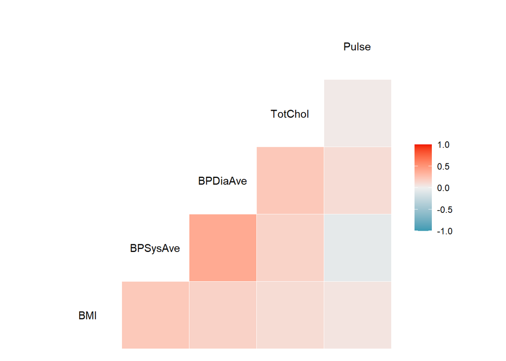

```r
clustering_data_health_risk = final_cleaned_data %>% dplyr::select("BMI","BPSysAve",
                                                                  "BPDiaAve", "TotChol",
                                                                  "Pulse")
ggcorr(clustering_data_health_risk)
```

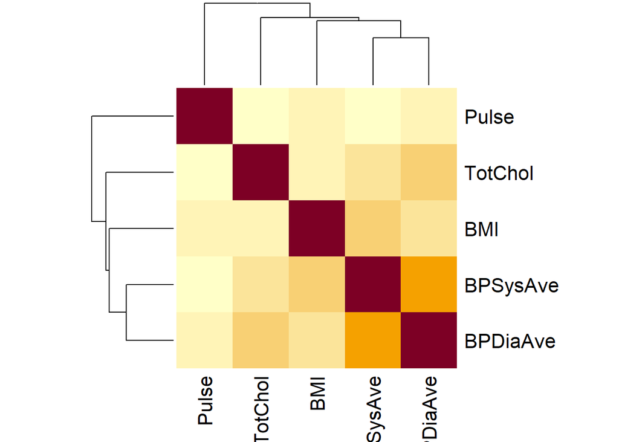

```r
heatmap(cor(clustering_data_health_risk),symm=T)
```

# K means

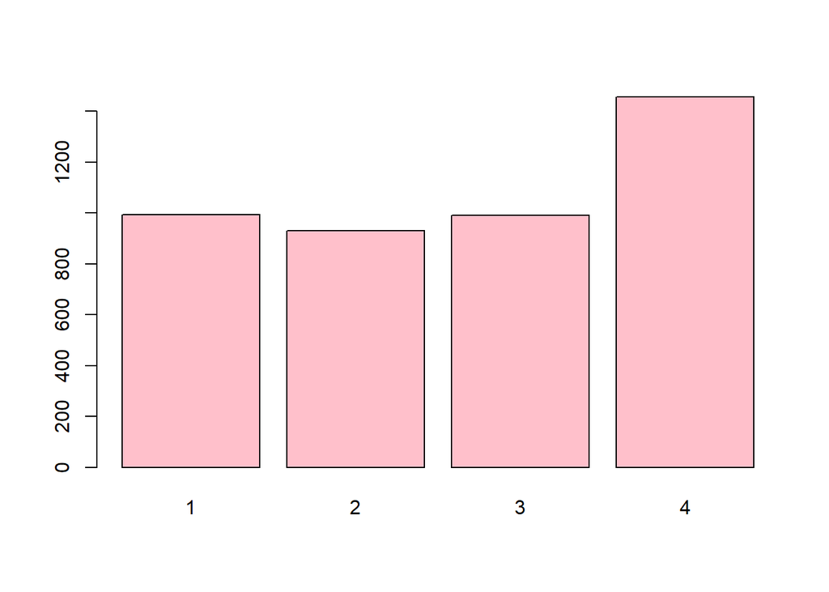

```r
k = 4
set.seed(1)
fit <- kmeans(clustering_data_health_risk, k, nstart = 25, iter.max = 100)
groups = fit$cluster
barplot(table(groups), col="pink")
```

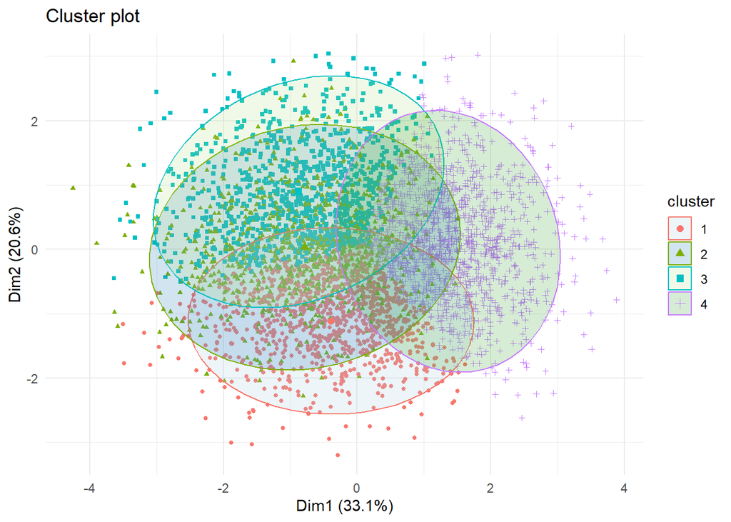

```r
fviz_cluster(fit, data = clustering_data_health_risk, geom = c("point"),ellipse.type = 'norm', pointsize=1)+
  theme_minimal()+scale_fill_brewer(palette="Paired")
```

Based on the kmeans clustering plot we can see that there is quite a lot of overlapping between the different clusters. We can now check the silhouette width to further determine the goodness of the clustering algorithm.

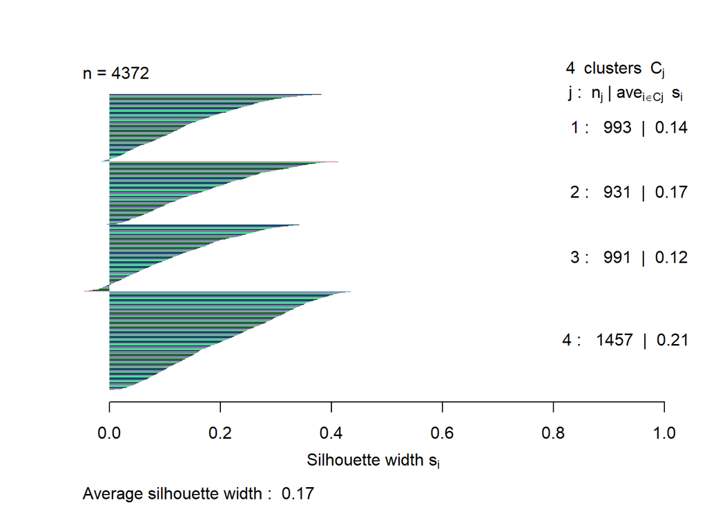

```r
d <- dist(clustering_data_health_risk, method="euclidean")
sil = silhouette(groups, d)
plot(sil, col=1:5, main="", border=NA)
```

```r
summary(sil)
```

```
## Silhouette of 4372 units in 4 clusters from silhouette.default(x = groups, dist = d) :
##  Cluster sizes and average silhouette widths:
##       993       931       991      1457
## 0.1418206 0.1723190 0.1229947 0.2103767
## Individual silhouette widths:
##     Min.  1st Qu.   Median     Mean  3rd Qu.     Max.
## -0.04853  0.07736  0.15388  0.16689  0.25103  0.44880
```

Values are closer to zero which indicates that the clusters may overlap. The negative minimum silhouette width also shows that there are some points that have been miscalculated.

We will now try to find what would be the ideal number of clusters using different approaches.

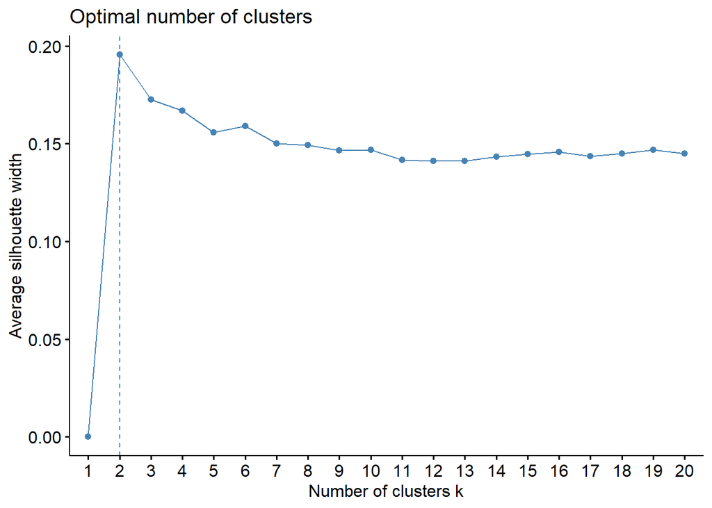

```r
fviz_nbclust(clustering_data_health_risk, kmeans, method = 'silhouette', k.max = 20, nstart = 25, iter.max = 100)
```

Here we can see that the optimal number of clusters will be 2.

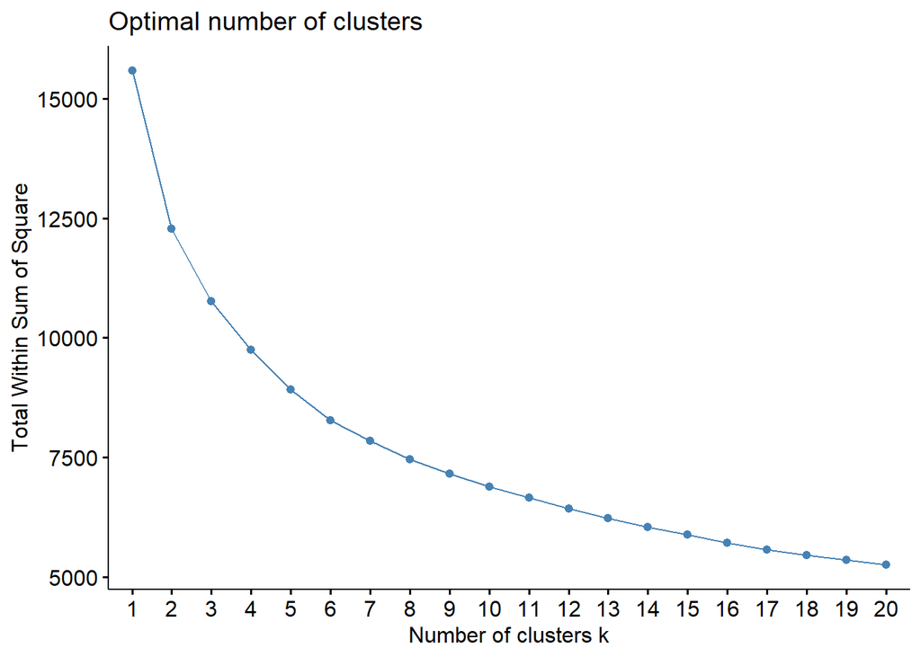

```r
fviz_nbclust(clustering_data_health_risk, kmeans, method = 'wss', k.max = 20,
             nstart = 25, iter.max = 100)
```

Judging by the Elbow Plot, we can assume that 4 or 5 cluster will be enough.

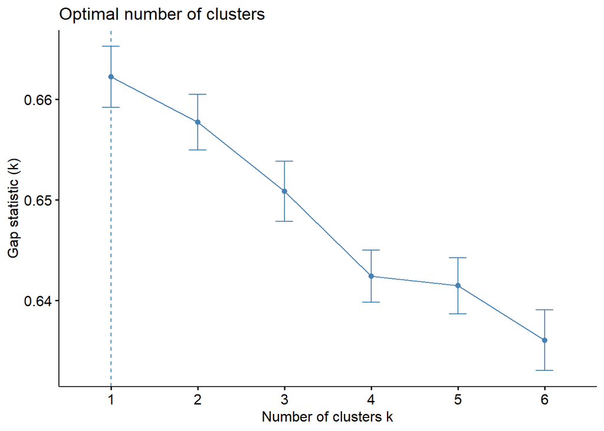

```r
fviz_nbclust(clustering_data_health_risk, kmeans, method = 'gap_stat', k.max = 6, nstart = 15, nboot = 50, iter.max = 50)
```

```r
# Please ignore any warnings shown. It takes a lot of time to be run.
```

The three graphs give us slightly different answers so we can try and do clustering with 2 centers and with 3 centers and after that decide which is better.

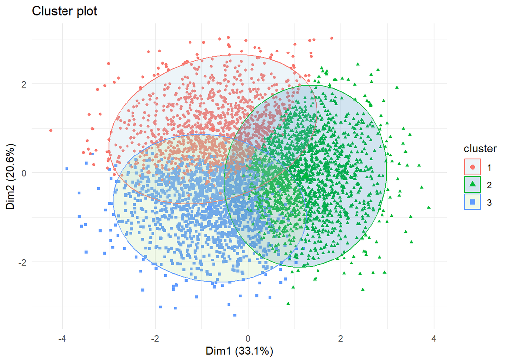

```r
k = 3
fit_3 <- kmeans(clustering_data_health_risk, k, nstart = 25, iter.max = 100)
groups_3 = fit_3$cluster
fviz_cluster(fit_3, data = clustering_data_health_risk, geom = c("point"),ellipse.type = 'norm', pointsize=1)+
  theme_minimal()+scale_fill_brewer(palette="Paired")
```

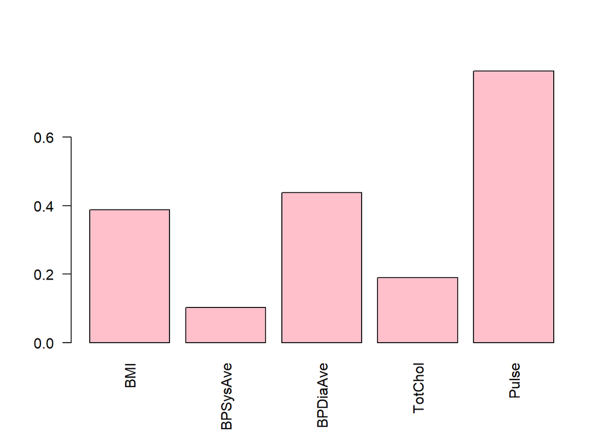

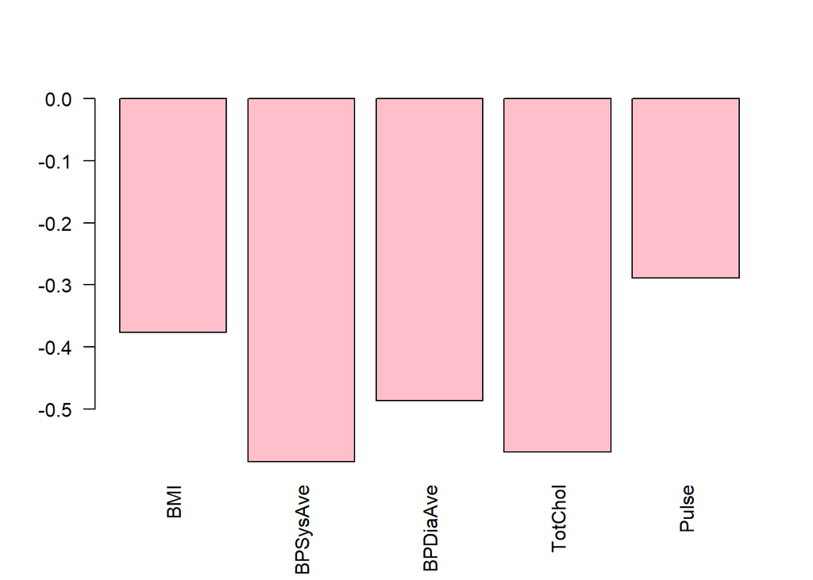

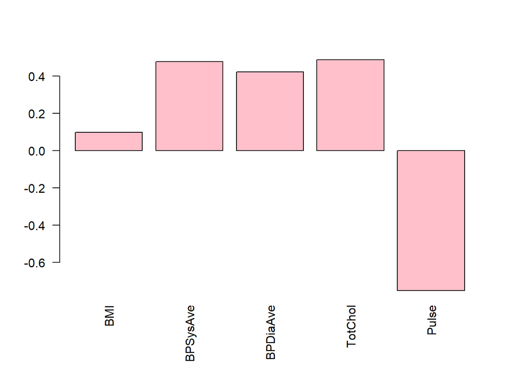

```r
centers_3=fit_3$centers
for(i in 1:3){
  b = barplot(centers_3[i,], las=2, col="pink")
}
```

```r
print(fit_3$size)
```

```
## [1] 1256 1718 1398
```

```r
print(fit_3$centers)
```

```
##           BMI   BPSysAve   BPDiaAve    TotChol      Pulse
## 1  0.38769736  0.1027518  0.4376234  0.1891136  0.7928917
## 2 -0.37634177 -0.5844705 -0.4868050 -0.5688613 -0.2891907
## 3  0.09887191  0.4792305  0.4222648  0.4886598 -0.7513537
```

Based on the centers we can interpret what each cluster will represent. Cluster 1 - 1256 individuals - BMI: 0.388 — higher-than-average BMI => could mean higher body weight - BPSysAve: 0.103 — close to the average - BPDiaAve: 0.438 — higher than average, but not by a lot - TotChol: 0.189 — slightly above average; could increase cardiovascular risk - Pulse: 0.793 — far above average; the group might be under more physical or metabolic stress, or may worse cardiovascular fitness

Interpretation of C1: This cluster show a group that has higher BMI and pulse rate and close to average blood pressure and cholesterol levels. These individuals could have an average rick of cardiovascular issues.

Cluster 2 - 1718 people: - BMI: -0.376 — people with lower-than-average BMI - BPSysAve: -0.584 — lower than average(but not severly so), which might mean that this group has healthier blood pressure levels - BPDiaAve: -0.487 — lower than average - TotChol: -0.569 — lower cholesterol levels, which is healthier - Pulse: -0.289 — The pulse rate is also slightly lower than average, which along with lower BMI, TotChol and blood pressure could mean better cardiovascular fitness

Interpretation of C2: This cluster shows healthier individuals with below average BMI, blood pressure, cholesterol and pulse. This could indicate that they have a lower risk of cardiovascular issues.

Cluster 3 - 1398 individuals - BMI: 0.099 — close to the average, normal body weight - BPSysAve: 0.479 — higher-than-average, could increase cardiovascular risk - BPDiaAve: 0.422 — higher-than-average - TotChol: 0.489 — higher levels, could increase cardiovascular risk - Pulse: -0.751 — lower than average; could mean better cardiovascular fitness or it could mean that the body has a compensatory response to manage higher blood pressure

Interpretation of C3: This cluster shows individuals with normal BMI, but higher blood pressure and cholesterol levels. They might have a higher risk for cardiovascular conditions and could benefit from changing their diet and contacting a doctor to find a way to regulate their blood pressure.

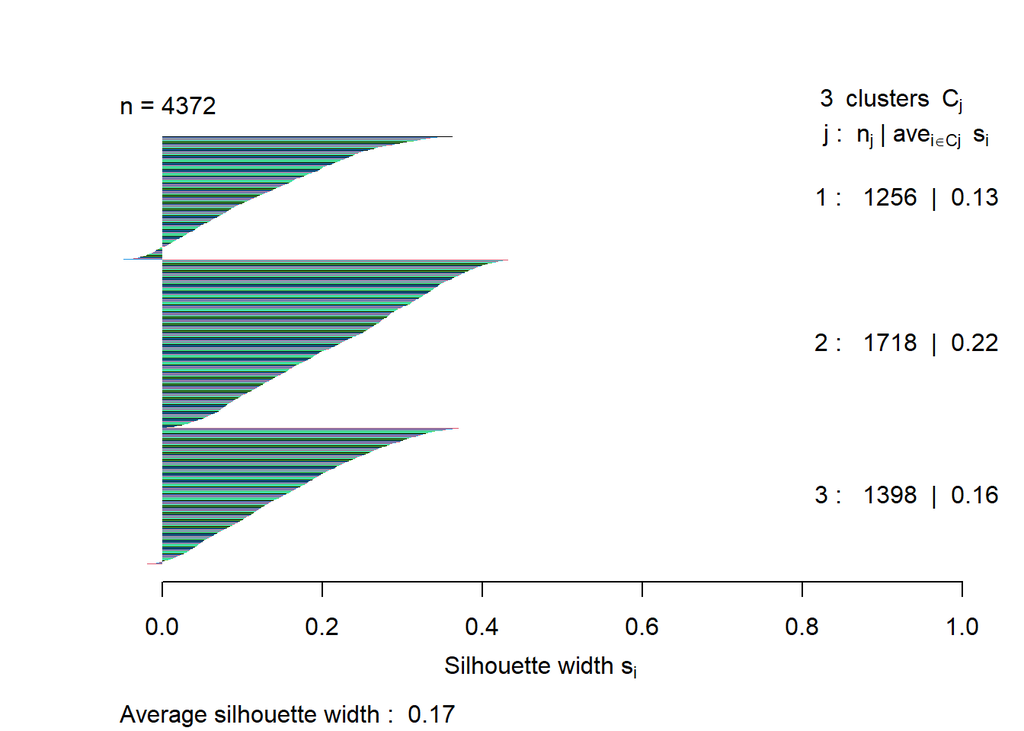

```r
d <- dist(clustering_data_health_risk, method="euclidean")
sil = silhouette(groups_3, d)
plot(sil, col=1:5, main="", border=NA)
```

```r
summary(sil)
```

```
## Silhouette of 4372 units in 3 clusters from silhouette.default(x = groups_3, dist = d) :
##  Cluster sizes and average silhouette widths:
##      1256      1718      1398
## 0.1253348 0.2193853 0.1574696
## Individual silhouette widths:
##     Min.  1st Qu.   Median     Mean  3rd Qu.     Max.
## -0.05336  0.08088  0.16416  0.17257  0.25919  0.45006
```

Values are close to zero which indicates that the clusters may overlap. The negative minimum silhouette width also shows that there are some points that have been miscalculated.

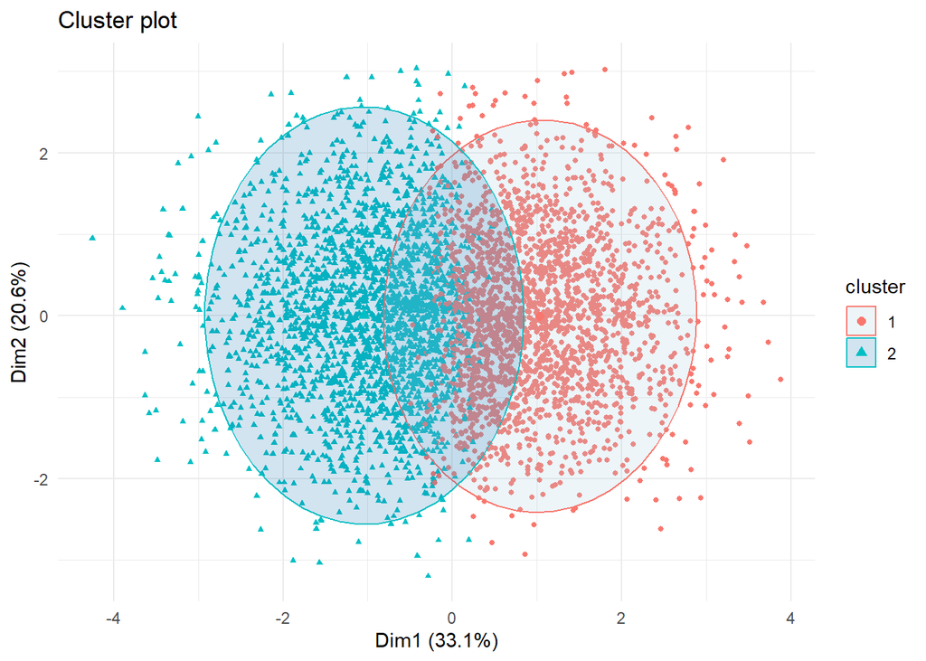

```r
k = 2
fit_2 <- kmeans(clustering_data_health_risk, k, nstart = 25, iter.max = 100)
groups_2 = fit_2$cluster
fviz_cluster(fit_2, data = clustering_data_health_risk, geom = c("point"),ellipse.type = 'norm', pointsize=1)+
  theme_minimal()+scale_fill_brewer(palette="Paired")
```

```r
print(fit_2$size)
```

```
## [1] 2194 2178
```

```r
print(fit_2$centers)
```

```
##          BMI   BPSysAve   BPDiaAve    TotChol       Pulse
## 1 -0.2958245 -0.5204895 -0.3978986 -0.4754041 -0.21898393
## 2  0.2881794  0.4301442  0.5402387  0.4528953 -0.03255248
```

Based on the centers we can interpret what each cluster will represent. Cluster 1 - 2194 individuals - BMI: - 0.296 - little below the average - BPSysAve: -0.520 — below average, relatively healthier blood pressure levels. - BPDiaAve: -0.398 — below average. - TotChol: -0.475 — lower; could mean a lower risk of cardiovascular issues. - Pulse: -0.219 — little below average; could mean good cardiovascular health

Interpretation of C1: This cluster shows people that are healthier and have below average BMI, blood pressure, cholesterol levels and pulse. They could have lower risk for cardiovascular issues.

Cluster 2 - 2178 individuals - BMI: 0.288 — higher BMI; could mean greater body weight - BPSysAve: 0.430 — higher than average, could mean higher chance cardiovascular risk - BPDiaAve: 0.540 — above average, supporting the potential for cardiovascular risk - TotChol: 0.453 — higher-than-average; increased risk for heart diseases - Pulse: -0.033 — close to average

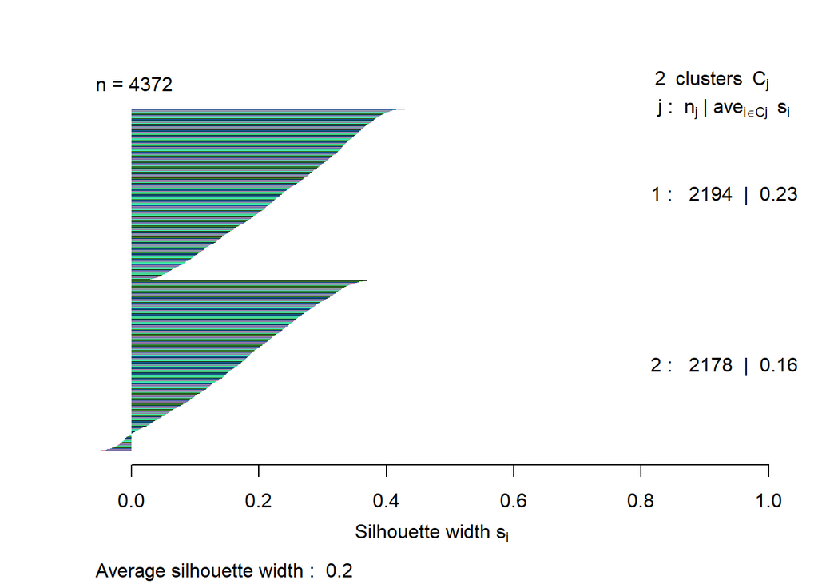

```r
d <- dist(clustering_data_health_risk, method="euclidean")
sil = silhouette(groups_2, d)
plot(sil, col=1:5, main="", border=NA)
```

```r
summary(sil)
```

```
## Silhouette of 4372 units in 2 clusters from silhouette.default(x = groups_2, dist = d) :
##  Cluster sizes and average silhouette widths:
##      2194      2178
## 0.2302622 0.1603961
## Individual silhouette widths:
##     Min.  1st Qu.   Median     Mean  3rd Qu.     Max.
## -0.05632  0.10679  0.19905  0.19546  0.28812  0.42861
```

Values are again close to zero, but they are better than for 3 clusters. From this we can assume that the clustering with only 2 centers is better than the one with 3.

# PAM

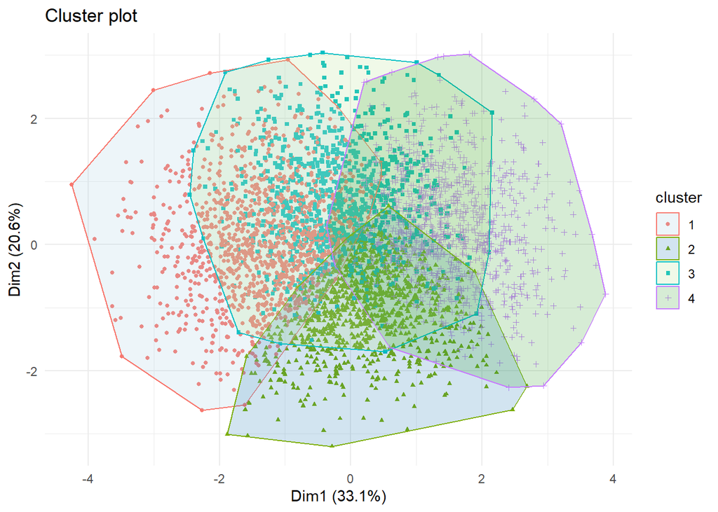

```r
fit_pam <- eclust(clustering_data_health_risk, "pam", stand=TRUE, k=4, graph=F)

fviz_cluster(fit_pam, data = clustering_data_health_risk, geom = c("point"), pointsize=1)+
  theme_minimal()+scale_fill_brewer(palette="Paired")
```

Number of groups by pam:

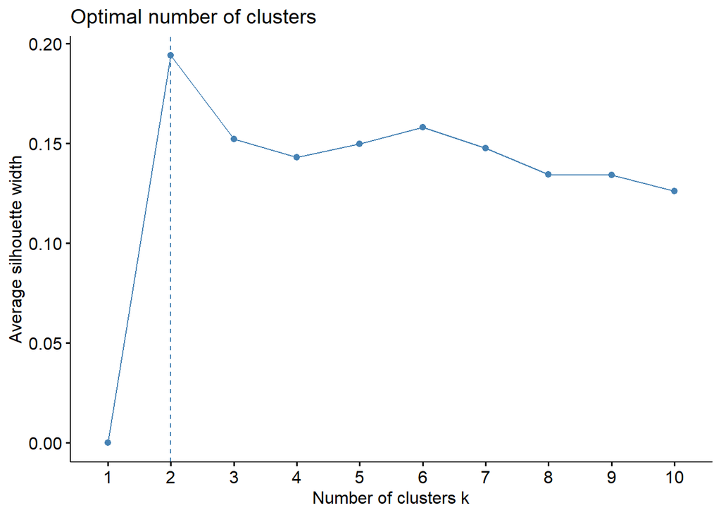

```r
fviz_nbclust(clustering_data_health_risk, pam, method = 'silhouette', k.max = 10)
```

```r
# This takes a minute to run!
```

Based on this graph, the optimal number of clusters is 2.

```r
fit_pam_2 <- eclust(clustering_data_health_risk, "pam", stand=TRUE, k=2, graph=F)
adjustedRandIndex(fit_2$cluster, fit_pam_2$clustering)
```

```
## [1] 0.7916127
```

The value(0.79) is close to 1, so we can say that the two classifications are in agreement.

```r
sil_pam <- silhouette(fit_pam_2$clustering, dist(clustering_data_health_risk))
summary(sil_pam)
```

```
## Silhouette of 4372 units in 2 clusters from silhouette.default(x = fit_pam_2$clustering, dist = dist(clustering_data_health_risk)) :
##  Cluster sizes and average silhouette widths:
##      2149      2223
## 0.1617745 0.2230706
## Individual silhouette widths:
##     Min.  1st Qu.   Median     Mean  3rd Qu.     Max.
## -0.09266  0.10372  0.19756  0.19294  0.28601  0.42480
```

Worse silhouette widths than k means.

# Kernel k-means

```r
fit_ker <- kkmeans(as.matrix(clustering_data_health_risk), centers=2, kernel="rbfdot")
```

```
## Using automatic sigma estimation (sigest) for RBF or laplace kernel
```

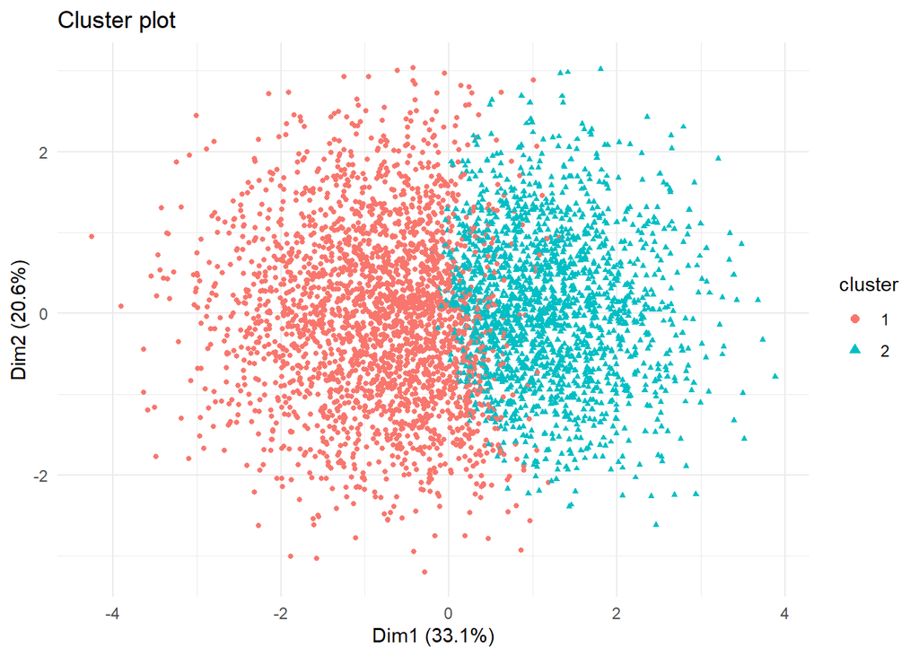

```r
#Also takes a minute to run!
object_ker = list(data = clustering_data_health_risk, cluster = fit_ker@.Data)
fviz_cluster(object_ker, geom = c("point"), ellipse=F,pointsize=1)+
  theme_minimal()+scale_fill_brewer(palette="Paired")
```

```r
adjustedRandIndex(fit_2$cluster, fit_ker@.Data)
```

```
## [1] 0.6704373
```

These are less of in agreement compared to the previous ones.

```r
clusters_ker <- fit_ker@.Data
kernel_matrix <- kernelMatrix(rbfdot(), as.matrix(clustering_data_health_risk))
sil_ker <- silhouette(clusters_ker, as.dist(1 - kernel_matrix))
summary(sil_ker)
```

```
## Silhouette of 4372 units in 2 clusters from silhouette.default(x = clusters_ker, dist = as.dist(1 - kernel_matrix)) :
##  Cluster sizes and average silhouette widths:
##       2552       1820
## 0.02599885 0.06525317
## Individual silhouette widths:
##     Min.  1st Qu.   Median     Mean  3rd Qu.     Max.
## -0.04128  0.01410  0.03448  0.04234  0.06197  0.18345
```

Very low score, indicating bad classification.

# EM clustering

```r
res.Mclust <- Mclust(clustering_data_health_risk)
summary(res.Mclust)
```

```
## ----------------------------------------------------
## Gaussian finite mixture model fitted by EM algorithm
## ----------------------------------------------------
##
## Mclust VEE (ellipsoidal, equal shape and orientation) model with 7 components:
##
##  log-likelihood    n df       BIC      ICL
##       -25997.65 4372 62 -52515.04 -56808.1
##
## Clustering table:
##    1    2    3    4    5    6    7
## 1022  828  737  432  540  293  520
```

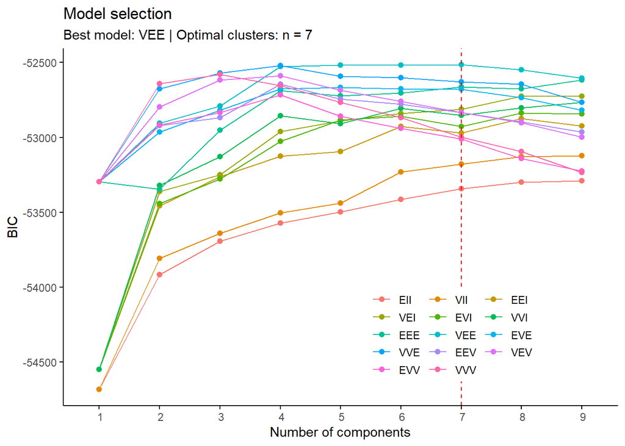

```r
fviz_mclust(object = res.Mclust, what = "BIC", pallete = "jco") +
  scale_x_discrete(limits = c(1:10))
```

The optimal number of cluster is 7 here.

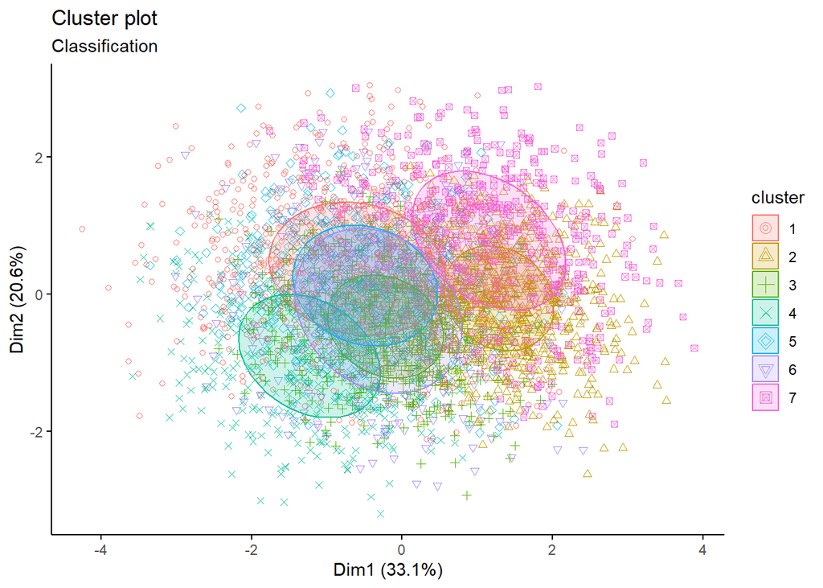

```r
fviz_mclust(object = res.Mclust, what = "classification", geom = "point",
            pallete = "jco")
```

```r
fit_7 <- kmeans(clustering_data_health_risk, 7, nstart = 25, iter.max = 100)
print(adjustedRandIndex(res.Mclust$classification, fit_7$cluster))
```

```
## [1] 0.2492618
```

As we can see by the low values they are not in agreement.

```r
sil_em <- silhouette(res.Mclust$classification, dist(clustering_data_health_risk))
summary(sil_em)
```

```
## Silhouette of 4372 units in 7 clusters from silhouette.default(x = res.Mclust$classification, dist = dist(clustering_data_health_risk)) :
##  Cluster sizes and average silhouette widths:
##        1022         828         737         432         540         293
## -0.01736362  0.15736536  0.13334305  0.07685776  0.16139390 -0.03916350
##         520
##  0.01587654
## Individual silhouette widths:
##     Min.  1st Qu.   Median     Mean  3rd Qu.     Max.
## -0.29279 -0.02462  0.08163  0.07501  0.17703  0.39302
```

The silhoutte widths of the EM clustering are also very low, indicating bad classification.